# Imdb Movies Analysis

In this Project , we all going through the **process of exploratory data analysis and visualization** of all the documented movies ever. Hence, we are going to go through a lot of data and answer questions as we go.

Here, we will define the question we will answer by using exploratory data analysis.

1. What is the range of movies in this dataset?
2. What is the earliest recorded animation movie in the dataset?
3. What are the top 10 longest movies in order?
4. >What are the number of comedy movies ? What proportion of total movies are comedy movies?
5. What are the number of movies which are both comedy and romance?
6. In the above dataset,what proprtion of shows do not have budget listed?
7. Of all short movies, which one is the shortest (in minutes)? Which one is the longest? How long are the shortest and the longest short movies?
8. What is the number of movies in each genre?
9. What is average rating of all movies in each genre? Plot a graph to demonstrate.
10. Use boxplots to demonstrate median,upper and lower quartiles of all the movies.
11. The 21st century brought about a huge change as we had access to better technology which resulted in better CGI and visual effects especially in action movies. Analyze how action movies fared before and after turn of the century.
12. For each of the first 6 genres (not including short movies) consider only movies from 1990 until the last year recorded and plot a function of the number of movies in this data base of corresponding genre produced by year, for years from 1990 until the last year recorded. For each of the 6 genres you should have one curve, and plot all the curves in the same figure
13. Use a histogram to depict distribution of movies since 1970 grouped by year.
14. Depict net change in number of movies recorded between 1990 and 2000.
15. Suppose one person picks a random comedy movie from 2000-2005 era. Generally, movies above imdb rating of 7 are considered 'good'. What is the probability that person will watch a 'good' movie.

```python
# Import necessary libraries
import warnings
import requests
from bs4 import BeautifulSoup
import pandas as pd
import numpy as np
import matplotlib.pyplot as plt
```

```python
#define a dataset df and read the dataset with all the movies
df  = pd.read_csv("movies.csv")
#head of the dataset
df.head(10)
```

|  | Unnamed: 0 | title | year | length | budget | rating | votes | r1 | r2 | r3 | ... | r9 | r10 | mpaa | Action | Animation | Comedy | Drama | Documentary | Romance | Short |
| --- | --- | --- | --- | --- | --- | --- | --- | --- | --- | --- | --- | --- | --- | --- | --- | --- | --- | --- | --- | --- | --- |
| 0 | 1 | $ | 1971 | 121 | NaN | 6.4 | 348 | 4.5 | 4.5 | 4.5 | ... | 4.5 | 4.5 | NaN | 0 | 0 | 1 | 1 | 0 | 0 | 0 |
| 1 | 2 | $1000 a Touchdown | 1939 | 71 | NaN | 6.0 | 20 | 0.0 | 14.5 | 4.5 | ... | 4.5 | 14.5 | NaN | 0 | 0 | 1 | 0 | 0 | 0 | 0 |
| 2 | 3 | $21 a Day Once a Month | 1941 | 7 | NaN | 8.2 | 5 | 0.0 | 0.0 | 0.0 | ... | 24.5 | 24.5 | NaN | 0 | 1 | 0 | 0 | 0 | 0 | 1 |
| 3 | 4 | $40,000 | 1996 | 70 | NaN | 8.2 | 6 | 14.5 | 0.0 | 0.0 | ... | 34.5 | 45.5 | NaN | 0 | 0 | 1 | 0 | 0 | 0 | 0 |
| 4 | 5 | $50,000 Climax Show, The | 1975 | 71 | NaN | 3.4 | 17 | 24.5 | 4.5 | 0.0 | ... | 0.0 | 24.5 | NaN | 0 | 0 | 0 | 0 | 0 | 0 | 0 |
| 5 | 6 | $pent | 2000 | 91 | NaN | 4.3 | 45 | 4.5 | 4.5 | 4.5 | ... | 14.5 | 14.5 | NaN | 0 | 0 | 0 | 1 | 0 | 0 | 0 |
| 6 | 7 | $windle | 2002 | 93 | NaN | 5.3 | 200 | 4.5 | 0.0 | 4.5 | ... | 4.5 | 14.5 | R | 1 | 0 | 0 | 1 | 0 | 0 | 0 |
| 7 | 8 | '15' | 2002 | 25 | NaN | 6.7 | 24 | 4.5 | 4.5 | 4.5 | ... | 4.5 | 14.5 | NaN | 0 | 0 | 0 | 0 | 1 | 0 | 1 |
| 8 | 9 | '38 | 1987 | 97 | NaN | 6.6 | 18 | 4.5 | 4.5 | 4.5 | ... | 4.5 | 24.5 | NaN | 0 | 0 | 0 | 1 | 0 | 0 | 0 |
| 9 | 10 | '49-'17 | 1917 | 61 | NaN | 6.0 | 51 | 4.5 | 0.0 | 4.5 | ... | 4.5 | 4.5 | NaN | 0 | 0 | 0 | 0 | 0 | 0 | 0 |

10 rows × 25 columns

**1.What is the range of movies in this dataset?**

```python
#Q1 Range of Movies
first_movie_year = min(df['year'])
latest_movie_year = max(df['year'])
#Print the range
print(str(first_movie_year)+"-"+str(latest_movie_year))
```

```
1893-2005
```

**2.What is the earliest recorded animation movie in the dataset?**

```python
anime =  df[df['Animation'] == 1]
sort_by_year = anime.sort_values(by='year',ascending=False)
sort_by_year = sort_by_year.reset_index(drop=True)
print("Earliest recorded Animation movie is"+str(sort_by_year.loc[0].at["title"]))
```

[output not shown]

**3.What are the top 10 longest movies in order?**

```python
#Q2 top 10 longest movies
sort_by_length = df.sort_values(by='length',ascending=False)
sort_by_length = sort_by_length.reset_index(drop=True)
listofmovies = []
for i in range(0, 10):
    listofmovies.append(sort_by_length['title'][i])
#Print the list of top 10 movies respectively
listofmovies
```

```
['Cure for Insomnia, The',
 'Longest Most Meaningless Movie in the World, The',
 'Four Stars',
 'Resan',
 'Out 1',
 'Ebolusyon ng isang pamilyang pilipino',
 'Shoah',
 'Commune (Paris, 1871), La',
 'Taiga',
 'Empire']
```

**4. What are the number of comedy movies ? What proportion of total movies are comedy movies?**

```python
com_movies = df[df['Comedy']==1]
print("Total no.of Comedy movies are "+str(com_movies.shape[0]))
```

```
Total no.of Comedy movies are 17271
```

```python
str(round(com_movies.shape[0]*100/df.shape[0],2))+" Percent of total movies are classified as Comedies"
```

```
'29.38 Percent of total movies are classified as Comedies'
```

**5. What are the number of movies which are both comedy and romance?**

```python
num_of_movies = df[df['Romance']==1]
num_of_movies = num_of_movies[num_of_movies['Comedy']==1]
print("Total number of rom-com movies in our data are "+str(len(num_of_movies)))
```

```
Total number of rom-com movies in our data are 2195
```

**6. In the above dataset,what proprtion of shows do not have budget listed?**

```python
num_of_shows = df[df['budget'].isna()]
str(round(num_of_shows.shape[0]*100/df.shape[0],2))+" Percent of movies do not have their budget listed"
```

```
'91.13 Percent of movies do not have their budget listed'
```

**7. Of all short movies, which one is the shortest (in minutes)? Which one is the longest? How long are the shortest and the longest short movies?**

```python
short_movies = df[df['Short']==1]
short_movies = short_movies.sort_values(by='length')
short_movies = short_movies.reset_index(drop=True)

shortest_short_movies = short_movies[short_movies['length']==min(short_movies['length'])]
di = {"Num of shortest short movies":str(shortest_short_movies.shape[0]),
      "Length":str(short_movies.loc[0].at["length"])}
di
```

```
{'Num of shortest short movies': '165', 'Length': '1'}
```

```python
longest_short_movie = {"Title":str(short_movies.loc[short_movies.shape[0]-1].at["title"]),
                    "Length":str(str(short_movies.loc[short_movies.shape[0]-1].at["length"]))}
longest_short_movie
```

```
{'Title': '10 jaar leuven kort', 'Length': '240'}
```

**8. What is the number of movies in each genre?**

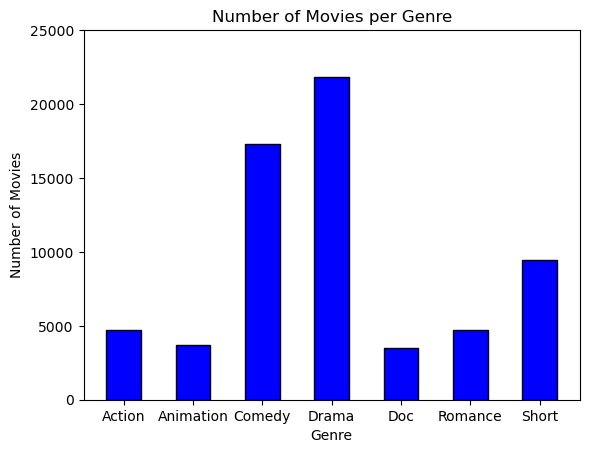

```python
#define x-axis value
x_bar = ['Action','Animation','Comedy','Drama','Doc','Romance','Short']
#extract-y-axis values
y_bar = [len(df[df['Action'] == 1]),len(df[df['Animation'] == 1]), len(df[df['Comedy'] == 1]),
        len(df[df['Drama'] == 1]), len(df[df['Documentary'] == 1]),len(df[df['Romance'] == 1]),len(df[df['Short'] == 1])]

#plot the bar
plt.bar(x_bar,y_bar,color='blue',width=0.5,edgecolor="black")


# Change the x axis title, y axis title, and main title of plot
plt.ylim(0,25000)
plt.xlabel("Genre")
plt.ylabel("Number of Movies")
plt.title("Number of Movies per Genre")
```

**9. What is average rating of all movies in each genre? Plot a graph to demonstrate.**

[figure not shown]

```python
# filter all genres
action = df[df['Action'] == 1]
anime =  df[df['Animation'] == 1]
comedy = df[df['Comedy']==1]
drama = df[df['Drama']==1]
doc = df[df['Documentary']==1]
romance = df[df['Romance']==1]
short = df[df['Short']==1]
#x-axis labels
x_bar = ['Action','Animation','Comedy','Drama','Doc','Romance','Short']
#y-axis extraction
y_bar = [action['rating'].mean(),anime['rating'].mean(),comedy['rating'].mean(),drama['rating'].mean()
         ,doc['rating'].mean(),romance['rating'].mean(),short['rating'].mean()]

#plot the bar
plt.bar(x_bar,y_bar,color='orange',width=0.5,edgecolor="black")
##################

# Change the x axis title, y axis title, and main title of plot and ylim
plt.ylim(0,10)
plt.xlabel("Genre")
plt.ylabel("Number of Movies")
plt.title("Number of Movies per Genre")
```

**10. Use boxplots to demonstrate median,upper and lower quartiles of all the movies? Then compare all the genres using boxplots.**

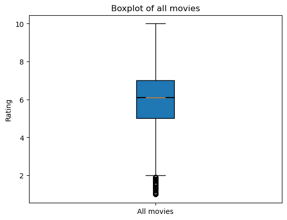

```python
labels = ['All movies']
plt.boxplot(df['rating'],notch=True,  # notch shape
                     vert=True,  # vertical box alignment
                     patch_artist=True,  # fill with color
                     labels=labels)
plt.ylabel("Rating")
plt.title("Boxplot of all movies")
```

This boxplot demonstrates that for all movies , 6 is the median and roughly 7 is upper quartile value and roughly 5 is lower quartile.

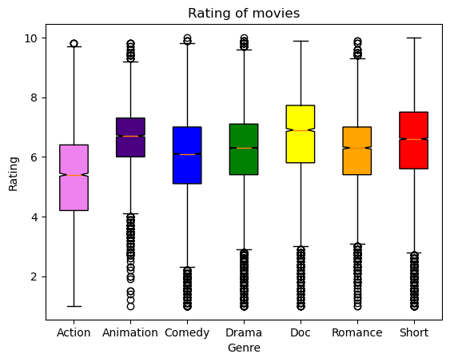

```python
#filter genres
action = df[df['Action'] == 1]
anime =  df[df['Animation'] == 1]
comedy = df[df['Comedy']==1]
drama = df[df['Drama']==1]
doc = df[df['Documentary']==1]
romance = df[df['Romance']==1]
short = df[df['Short']==1]

#combine the data
data = [action['rating'],anime['rating'],comedy['rating'],drama['rating']
         ,doc['rating'],romance['rating'],short['rating']]
#x-axis
labels = ['Action','Animation','Comedy','Drama','Doc','Romance','Short']
#colors of boxplots
colors = ["violet","indigo","blue","green","yellow","orange","red"]
a= plt.boxplot(data,notch=True,  # notch shape
                     vert=True,  # vertical box alignment
              patch_artist=True,labels=labels) # fill with color
#set colors
for bplot in a:
    for patch, color in zip(a['boxes'], colors):
        patch.set_facecolor(color)
# Change the x axis title, y axis title, and main title of plot
plt.xlabel("Genre")
plt.ylabel("Rating")
plt.title("Rating of movies")
```

By making boxplots, we can see greater variation than we could see in mean. We can see a lot of data like only 25% of action movies get a rating rouhly 6.3 whereas more than half of documentaries are rated about 6.3

**11. The 21st century brought about a huge change as we had access to better technology which resulted in better CGI and visual effects especially in action movies. Analyze how action movies fared before and after turn of the century.**

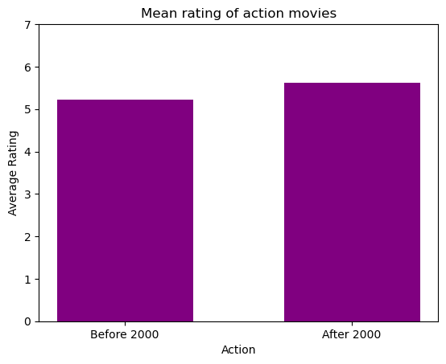

```python
action_before2000 = action[action['year']<2000]
action_after2000 = action[action['year']>=2000]

x_bar = ['Before 2000','After 2000']
y_bar = [action_before2000['rating'].mean(),action_after2000['rating'].mean()]

plt.bar(x_bar,y_bar,color='purple',width=0.6)
##################

# Change the x axis title, y axis title, and main title of plot
plt.xlabel("Action")
plt.ylim(0,7)
plt.ylabel("Average Rating")
plt.title("Mean rating of action movies")
```

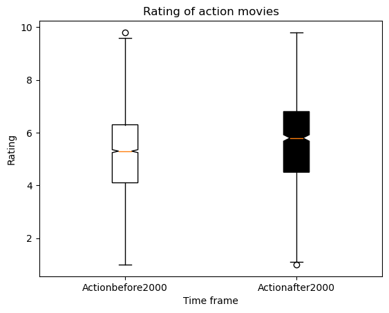

```python
data = [action_before2000['rating'],action_after2000['rating']]
labels = ['Actionbefore2000','Actionafter2000']
colors = ["white","black"]
a= plt.boxplot(data,notch=True,  # notch shape
                     vert=True,  # vertical box alignment
                     patch_artist=True,labels=labels) # fill with color
for bplot in a:
    for patch, color in zip(a['boxes'], colors):
        patch.set_facecolor(color)
# Change the x axis title, y axis title, and main title of plot
plt.xlabel("Time frame")
plt.ylabel("Rating")
plt.title("Rating of action movies")
```

**12.For each of the first 6 genres (not including short movies) consider only movies from 1990 until the last year recorded and plot a function of the number of movies in this data base of corresponding genre produced by year, for years from 1990 until the last year recorded. For each of the 6 genres you should have one curve, and plot all the curves in the same figure**

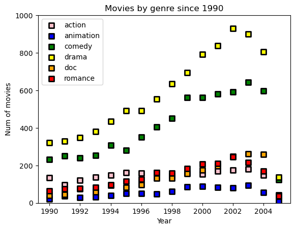

```python
#group all genres by year
action_by_year = action[action['year']>=1990].groupby('year')['Action'].count()
anime_by_year = anime[anime['year']>=1990].groupby('year')['Animation'].count()
com_by_year = comedy[comedy['year']>=1990].groupby('year')['Comedy'].count()
drama_by_year = drama[drama['year']>=1990].groupby('year')['Drama'].count()
doc_by_year = doc[doc['year']>=1990].groupby('year')['Documentary'].count()
rom_by_year =romance[romance['year']>=1990].groupby('year')['Romance'].count()
#initialize empty lists
yearlist = []
animlist = []
actionlist = []
comlist = []
dramalist = []
doclist = []
romlist = []
#fill the lists with data
for i in range(1990,2006):
    yearlist.append(i)
    actionlist.append(action_by_year[i])
    animlist.append(anime_by_year[i])
    comlist.append(com_by_year[i])
    dramalist.append(drama_by_year[i])
    doclist.append(doc_by_year[i])
    romlist.append(rom_by_year[i])
#plot all scatterplots
plt.scatter(yearlist, actionlist, c ="pink",
            linewidths = 2,
            marker ="s",
            edgecolor ="black",label="action",
            s = 50)
plt.scatter(yearlist, animlist, c ="blue",
            linewidths = 2,
            marker ="s",
            edgecolor ="black",label="animation",
            s = 50)

plt.scatter(yearlist, comlist, c ="green",
            linewidths = 2,
            marker ="s",
            edgecolor ="black",label="comedy",
            s = 50)

plt.scatter(yearlist, dramalist, c ="yellow",
            linewidths = 2,
            marker ="s",
            edgecolor ="black",label="drama",
            s = 50)

plt.scatter(yearlist, doclist, c ="orange",
            linewidths = 2,
            marker ="s",
            edgecolor ="black",label="doc",
            s = 50)

plt.scatter(yearlist, romlist, c ="red",
            linewidths = 2,
            marker ="s",
            edgecolor ="black",label="romance",
            s = 50)
#plot ylim,xlabel,ylabel and legend
plt.ylim(0,1000)
plt.xlabel("Year")
plt.ylabel("Num of movies")
plt.title("Movies by genre since 1990")
plt.legend()
plt.show()
```

**13. Use a histogram to depict distribution of movies since 1970 grouped by year.**

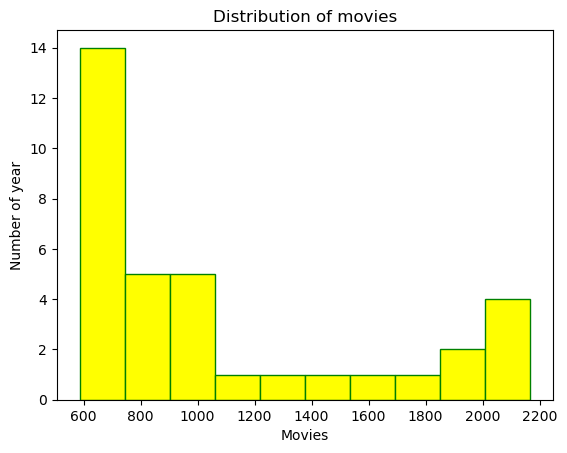

```python
movies_by_year =  df[df['year']>=1970].groupby('year')['title'].count()
hist_data = []
for i in range(1970,2005):
    hist_data.append(movies_by_year[i])

fig = plt.figure()
ax = fig.add_subplot(1,1,1)
ax.hist(hist_data,bins=10,color='yellow',alpha=1,edgecolor='green')
ax.set_xlabel('Movies')
ax.set_ylabel('Number of year')
ax.set_title("Distribution of movies")
```

600-800 seems to be the sweet spot for number of movies every year. However , there are huge disparities in this data. We cannot get a definite trend to make any other conclusions except that there was a high change of between 600-800 movies being produced from 1970-2005

**14. Depict net change in number of movies recorded between 1990 and 2000.**

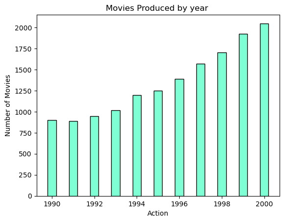

```python
#filter movies between 1990 and 2000
filter_movies = df[df['year']>=1990]
filter_movies = filter_movies[filter_movies['year']<=2000]
#group by year
movies_by_year =  filter_movies.groupby('year')['title'].count()
bar_data = []
year_data = []
#set the data in lists
for i in range(1990,2001):
    year_data.append(i)
    bar_data.append(movies_by_year[i])
#set x-axis and y-axis values
x_bar = year_data
y_bar = bar_data

#plot the bar chart
plt.bar(x_bar,y_bar,color='aquamarine',width=0.4,edgecolor="black")
##################

# Change the x axis title, y axis title, and main title of plot
plt.xlabel("Action")

plt.ylabel("Number of Movies")
plt.title("Movies Produced by year ")
```

This bar graph demonstrates the number of movies between 1990 and 2000. We can see a rising trend in number of movies recorded in this dataset.Let us now draw another plot to represent net change

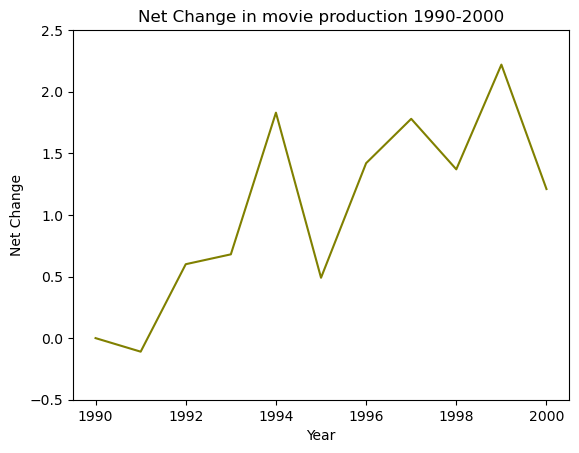

```python
net_list = [0]
#add values of net change to a list
for i in range(1,11):
    net_list.append((bar_data[i]-bar_data[i-1])/100)
#set x and y axis
y_axis = net_list
x_axis = x_bar
#plot the graph
plt.plot(x_axis,y_axis,color="olive")

# Change the x axis title, y axis title,ylim and main title of plot
plt.ylim(-0.5,2.5)
plt.xlabel("Year")
plt.ylabel("Net Change")
plt.title("Net Change in movie production 1990-2000")
```

Positive net change indicates number of movies recorded has increased as we have gotten closer to century. The only time number of recorded movies went down was between 1990 and 1991.

**15. Suppose one person picks a random comedy movie from 2000-2005 era. Generally, movies above imdb rating of 7 are considered 'good'. What is the probability that person will watch a 'good' movie.**

```python
comedy_movie = comedy[comedy['year']>=2000]
good_rating_comedy = comedy_movie[comedy_movie['rating']>=7]
print("Probability that the person ends up watching a good comedy movie is "+str(round(len(good_rating_comedy)/len(comedy_movie),2)))
```

```
Probability that the person ends up watching a good comedy movie is 0.3
```